# Colon chemotherapy: sorted-effects pilot

Three-year mortality, patient profiles and a held-out ranking check

Published

October 22, 2026

# Colon chemotherapy: a promising ranking

The specified interaction model finds variation in estimated benefit, and its ranking has support in one held-out sample. The missing-baseline sensitivity is weaker. This is a useful clinical example to discuss, with **preliminary internal evidence rather than an established treatment rule**.

This analysis compares randomized levamisole plus fluorouracil with observation after resection of colon cancer. The endpoint is **death within three years**. The plan was written before fitting: two models, six specified interactions, twelve classification characteristics, one validation split and three kinds of sensitivity check. Crude arm risks and data availability had already been inspected. This is the third trial pilot considered for this journal club; the reported p-values do not adjust for the whole exploration.

Analysis plan · Data and exclusions · Analysis code · Validation code

## What data enter the analysis?

The public dataset has two records per person: recurrence and death. We use one death record per person and the two selected arms. The third arm, levamisole alone, is outside this comparison.

| Arm | Randomized | Known three-year outcome | Deaths by three years | Crude risk (%) | Primary complete baselines |
| --- | --- | --- | --- | --- | --- |
| Observation | 315 | 314 | 109 | 34.7 | 304 |
| Levamisole + fluorouracil | 304 | 304 | 78 | 25.7 | 289 |

- **619 participants** in the selected comparison; ages 18–85, with 312 women and 307 men.
- **618 known endpoints.** One observation-arm patient was censored early and has unknown three-year status. Early censoring is not coded as survival.
- **593 in the primary model and reference population.** Twelve node counts and thirteen differentiation grades are missing among the 618 with known endpoints. We report the all-618 sensitivity separately.

Among known outcomes, the crude risk reduction is **9.06 percentage points**. Assigning the one unknown outcome either way gives crude differences of 8.95 to 9.26 pp. These are missing-outcome bounds, not sampling confidence limits.

## Two models, similar average benefits

Both models include age, sex, age-by-sex, positive-node count, differentiation, local extent, obstruction, tumour adherence to nearby organs and the recorded surgery-to-registration interval. Age uses a three-degree-of-freedom natural spline; node count uses log(1 + count).

The common-odds-ratio model has 13 coefficients. The interaction model has 19: it adds treatment interactions with age, sex, age-by-sex, log node count, poor differentiation and extent at least to the serosa.

| Model | Average reduction (pp) | 10th percentile (pp) | 90th percentile (pp) |
| --- | --- | --- | --- |
| Common odds ratio | 7.95 | 4.81 | 10.80 |
| Six treatment interactions | 8.14 | -9.76 | 27.27 |

The interaction model estimates an average reduction of **8.14 pp**, with a native 95% bootstrap interval of **1.42 to 14.86 pp**. The joint six-interaction test gives **p = 0.014**. That test concerns variation on the log-odds scale, not constancy of risk differences.

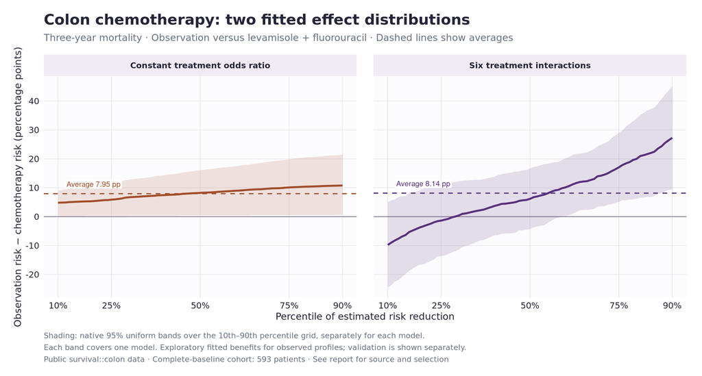

- The average benefit is similar under both specifications.
- Absolute benefit varies even under a common odds ratio, through baseline risk.
- Interactions produce a much wider fitted distribution. The lower fitted tail includes negative estimates, but its confidence band includes zero. This **does not establish treatment harm** for those profiles.
- Bands are the original package’s 95% uniform bands over the displayed grid, separately for each model. They condition on the observed reference profiles.

## Who is in the fitted tails?

The bottom and top deciles each contain **60 profiles**. Both are defined across the same 593 participants, using the fitted risk reduction regardless of actual treatment allocation.

The bottom tail is entirely female and mostly women younger than 55. The top tail is mostly male and has a higher mean positive-node count. These describe the model’s selected groups; they are not estimates of benefit for all women or all men.

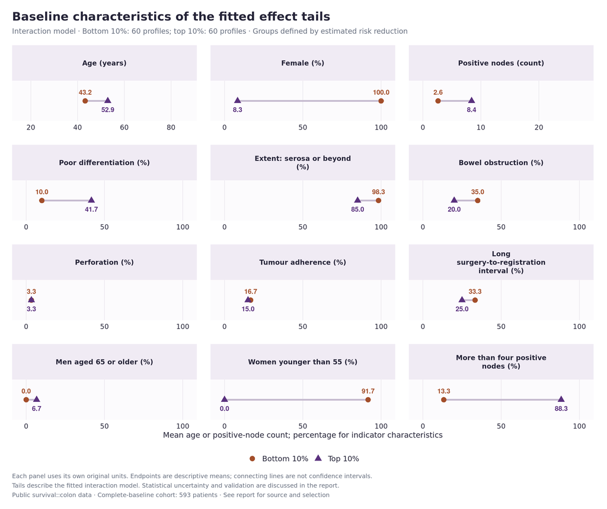

- Mean age is **43.2 versus 52.9 years**.
- Mean positive-node count is **2.6 versus 8.4**.
- The lines connect descriptive means; they are not confidence intervals.
- The combined demographic rows overlap with age and sex. They are not independent discoveries of treatment interactions.

### Classification uncertainty

The native classification bootstrap had a numerical failure in this dataset. Its large fitting weights caused 141 of 499 logistic fits not to converge, and 137 draws had undefined tail means. We do not use its resulting p-values.

The table below uses a **separate stabilized reconstruction** with the same 499 draws, model, weights, threshold definitions and moment formulas. Each scaled-weight fit starts from the converged ordinary count-weight fit. All 499 then converge, with no undefined moments or discarded draws. This numerical amendment was recorded after the first run; it is not unmodified native package output.

| Characteristic | Bottom 10% | Top 10% | Top minus bottom | Bootstrap SE | Joint p |
| --- | --- | --- | --- | --- | --- |
| Age (years) | 43.2 | 52.9 | 9.7 | 7.1 | 0.872 |
| Female (%) | 100.0 | 8.3 | -91.7 | 21.4 | 0.042 |
| Positive nodes (count) | 2.6 | 8.4 | 5.8 | 2.2 | 0.297 |
| Poor differentiation (%) | 10.0 | 41.7 | 31.7 | 27.7 | 0.948 |
| Extent: serosa or beyond (%) | 98.3 | 85.0 | -13.3 | 17.4 | 0.992 |
| Bowel obstruction (%) | 35.0 | 20.0 | -15.0 | 9.6 | 0.762 |
| Perforation (%) | 3.3 | 3.3 | 0.0 | 3.7 | 1.000 |
| Tumour adherence (%) | 16.7 | 15.0 | -1.7 | 10.5 | 1.000 |
| Long surgery-to-registration interval (%) | 33.3 | 25.0 | -8.3 | 10.8 | 0.990 |
| Men aged 65 or older (%) | 0.0 | 6.7 | 6.7 | 14.2 | 1.000 |
| Women younger than 55 (%) | 91.7 | 0.0 | -91.7 | 21.1 | 0.040 |
| More than four positive nodes (%) | 13.3 | 88.3 | 75.0 | 22.1 | 0.132 |

Percentage-row differences and SEs are in percentage points. Joint p-values adjust across the twelve specified characteristics. The female and younger-women rows are around .04 in this reconstruction; with only 499 draws and overlapping traits, these are tentative profile differences. CA p-values do not test that a characteristic modifies treatment effects. No native moment confidence intervals are claimed.

## Does the ranking work in held-out patients?

One fixed split assigns **296 patients to training and 297 to validation**, stratified on randomized treatment only. Both models are fitted on training outcomes. Their predictions then define three equally sized benefit groups in validation data. No alternative split was tried.

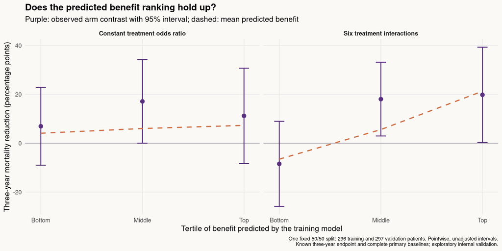

The interaction model predicts a top-minus-bottom tertile difference of **27.80 pp**. The observed difference is **28.26 pp** (95% interval **2.11 to 54.40 pp**). This is consistent with the predicted direction, but the interval is wide. Its raw p-value is 0.034 and its Holm-adjusted p-value across the two rankings is 0.068.

| Model | Ranking slope | 95% interval | Raw p (slope = 0) | Holm p (two rankings) |
| --- | --- | --- | --- | --- |
| Common odds ratio | 2.13 | -5.03 to 9.30 | 0.560 | 0.560 |
| Six treatment interactions | 1.10 | 0.24 to 1.97 | 0.013 | 0.025 |

The ranking slope regresses an AIPW benefit pseudo-outcome on frozen predicted benefit, using training-only risk models and HC3 standard errors. A positive slope supports agreement between prediction and validation outcomes; one corresponds to linear calibration. The interaction slope is **1.10**, with a 95% interval of **0.24 to 1.97**.

The plotted group intervals are pointwise and unadjusted. The two-ranking Holm adjustment applies separately to slopes and tail contrasts, not to every diagnostic in this project. The full-sample interaction test and this split check use overlapping data and are not independent replications. This is internal validation of a model ranking, not external validation of a clinical treatment rule.

## How sensitive is the result?

The specified sensitivity checks matter here:

- **All 618 known endpoints:** filling missing node counts with the baseline median of 2, retaining missing-value indicators, and representing unknown differentiation explicitly gives an average reduction of 8.36 pp. The six-interaction test weakens to **p = 0.054**. This is a working missing-data analysis, not multiple imputation; both the model and reference population change.
- **One unknown endpoint:** assigning that person either outcome gives interaction-model average reductions from 8.01 to 8.36 pp.
- **Node coding:** the source’s node count and binary indicator disagree for eight primary patients. Comparing two identical binary-node models on the same 593 people gives an interaction-ranking correlation of 0.992. These binary models are sensitivity checks, not replacements selected by their results.

The primary and sensitivity results should be shown together. We have some internal support for the ranking, with unresolved uncertainty about its stability and applicability beyond this analysis population.

## What this adds to the journal club

This is a stronger candidate for the clinical story than the first two pilots:

1. The average benefit is easy to see and clinically interpretable.
2. The fitted distribution and twelve-row table make the patient profiles concrete.
3. Held-out data provide some support for the ranking, while the missing-data sensitivity prevents an overly neat conclusion.

The package’s numerical failure is a useful optional software discussion. For the main talk, keep attention on the clinical contrast, effect scale, profiles and validation. These historical therapies and exploratory results do not establish a present-day treatment recommendation or a newly discovered clinical interaction. A focused literature check is still needed before any novelty claim.

The source dictionary identifies the original 1990 and 1995 trial reports, but their full text could not be retrieved here. We have not established whether these age, sex or nodal patterns were reported previously. Our three-year absolute-risk contrast also differs from a full time-to-event analysis.

## Reproduce and inspect

```bash
source /workspace/.tools/activate
python3 scripts/fetch-colon-data.py --verify-only
Rscript scripts/analyze-colon.R
Rscript scripts/validate-colon-ranking.R
Rscript scripts/verify-colon-inference.R
Rscript scripts/verify-colon-inference.R stabilize
Rscript scripts/plot-colon.R
quarto render colon-pilot.qmd --to html
```

Both native SPE/APE bootstrap reconstructions match exactly, including bands and intervals. All 998 count-weight SPE fits converge. The independent audit also reproduces the native CA failure before applying the documented initialization change. Stable weighted fits agree with the count-weight fits in predicted risk to within about 0.000001. These are numerical checks, not a repeated-sampling coverage study or proof of model correctness.

Numerical audit code · [All result tables](https://github.com/valentinklotzbuecher/jcod/tree/main/results/colon) · Pinned data and source hashes · IST comparison

The public data are distributed with the survival package. Its dictionary cites Laurie et al. (1989), Moertel et al. (1990) and the final Moertel et al. (1995) report, and documents the node-variable inconsistency. The exact allocation algorithm and center structure have not been reconstructed here. Inference uses working logistic models and patient-level resampling.